# Donor Profile: European Commission - Humanitarian Aid & Civil Protection

## Focus Portfolio

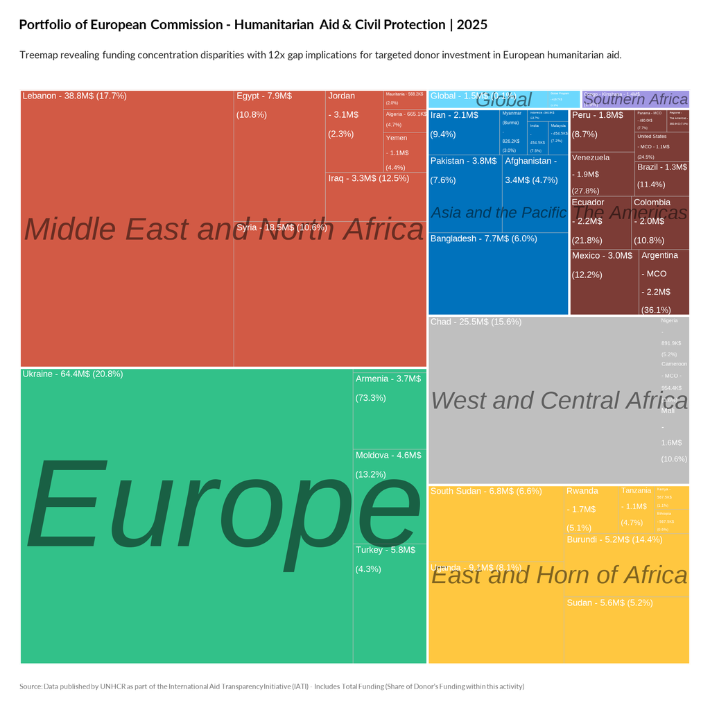

TRUE

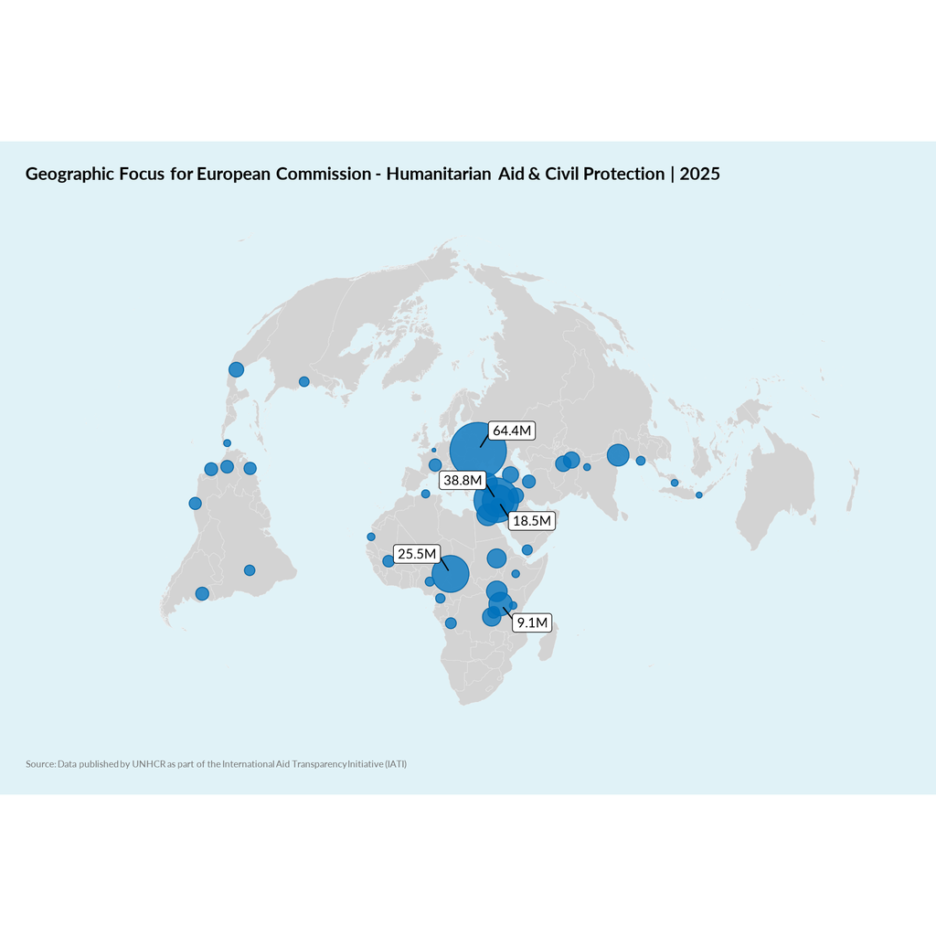

TRUE

## Earmarking Behavior

European Commission’s earmarked humanitarian aid in 2025 reveals substantial regional funding disparities, with total allocations ranging from $1.4M to nearly $79M across eight regions. This concentration underscores a critical opportunity to strategically leverage additional resources in underfunded areas that currently receive less than 30% of the median funding level of $24M. Investing in these lower-funded regions presents an impact multiplier by extending protection and aid where gaps risk escalating humanitarian crises. Furthermore, the stark variance in funding—evidenced by a standard deviation of nearly $30M—signals the need for refined allocation strategies to balance emergency response and resilience building. Donor investment focused on these dynamics can enhance accountability and operational agility by channeling funds to regions where marginal inputs yield outsized humanitarian outcomes. We recommend prioritizing partnerships with regional actors and deploying innovative funding mechanisms to fill critical gaps efficiently. Immediate executive action to recalibrate resource distribution will maximize European Commission aid impact and affirm donor confidence in transparent, data-driven decision-making.

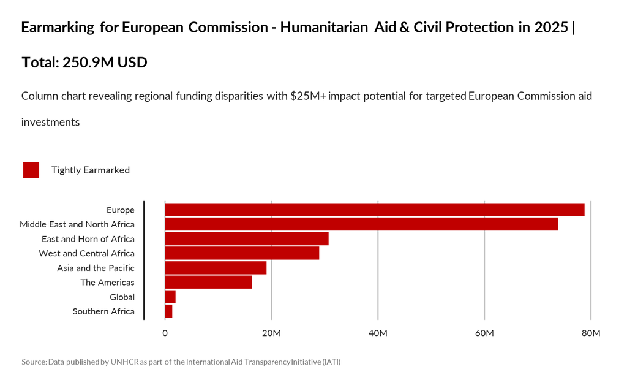

TRUE

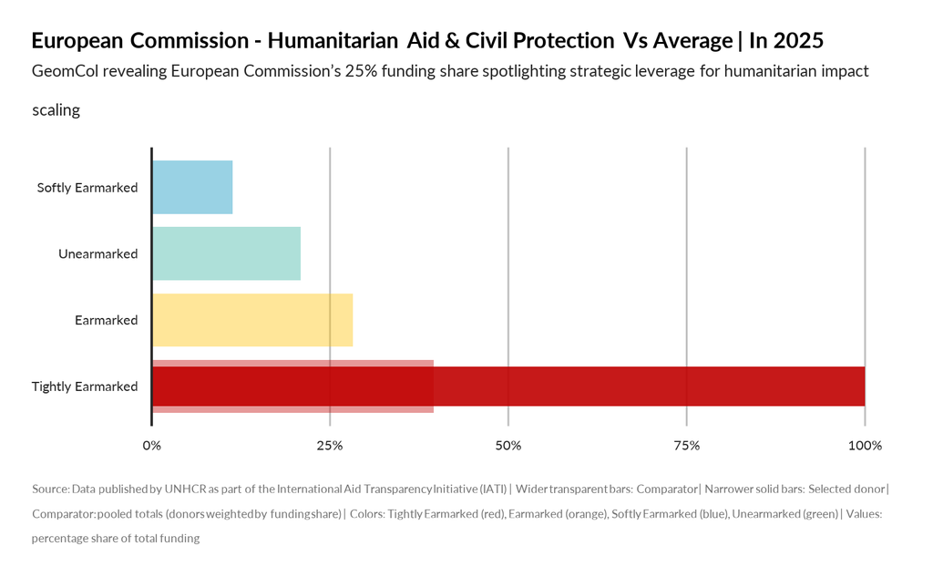

TRUE